# Student_Result_Prediction_DecisionTree_Algorithm

Anirudh R N

25 January 2018

# 1)Package Used

```r
#install.packages("markdown")
#install.packages("DT")
#install.packages("ggplot")
#install.packages("c50")
#install.packages("rpart")
#install.packages("randomForest")
#install.packages("caret")
#install.packages("Fselector)
#install.packages("grid")
#install.packages("libcoin")
#install.packages("mvtnorm")
#install.packages("rpart")
#install.packages("gmodels")
```

# 2)Data Setup

Read the Data Set by URL:

```r
temp <- tempfile()
download.file("http://archive.ics.uci.edu/ml/machine-learning-databases/00356/student.zip",temp,mode = "wb")
unzip(temp,"student-mat.csv")
```

View the Data:

```r
studentDataSet <- read.csv("student-mat.csv",sep = ";",header = T)
unlink(temp)
```

```r
library(DT)
datatable(head(studentDataSet))
```

|  | school | sex | age | address | famsize | Pstatus | Medu | Fedu | Mjob | Fjob | reason | guardian | traveltime | studytime | failures | schoolsup | famsup | paid | activities | nursery | higher | internet | romantic | famrel | freetime | goout | Dalc | Walc | health | … |
| --- | --- | --- | --- | --- | --- | --- | --- | --- | --- | --- | --- | --- | --- | --- | --- | --- | --- | --- | --- | --- | --- | --- | --- | --- | --- | --- | --- | --- | --- | --- |
| 1 | GP | F | 18 | U | GT3 | A | 4 | 4 | at_home | teacher | course | mother | 2 | 2 | 0 | yes | no | no | no | yes | yes | no | no | 4 | 3 | 4 | 1 | 1 | 3 | … |
| 2 | GP | F | 17 | U | GT3 | T | 1 | 1 | at_home | other | course | father | 1 | 2 | 0 | no | yes | no | no | no | yes | yes | no | 5 | 3 | 3 | 1 | 1 | 3 | … |
| 3 | GP | F | 15 | U | LE3 | T | 1 | 1 | at_home | other | other | mother | 1 | 2 | 3 | yes | no | yes | no | yes | yes | yes | no | 4 | 3 | 2 | 2 | 3 | 3 | … |
| 4 | GP | F | 15 | U | GT3 | T | 4 | 2 | health | services | home | mother | 1 | 3 | 0 | no | yes | yes | yes | yes | yes | yes | yes | 3 | 2 | 2 | 1 | 1 | 5 | … |
| 5 | GP | F | 16 | U | GT3 | T | 3 | 3 | other | other | home | father | 1 | 2 | 0 | no | yes | yes | no | yes | yes | no | no | 4 | 3 | 2 | 1 | 2 | 5 | … |
| 6 | GP | M | 16 | U | LE3 | T | 4 | 3 | services | other | reputation | mother | 1 | 2 | 0 | no | yes | yes | yes | yes | yes | yes | no | 5 | 4 | 2 | 1 | 2 | 5 | … |

```r
str(studentDataSet)
```

```
## 'data.frame':    395 obs. of  33 variables:
##  $ school    : Factor w/ 2 levels "GP","MS": 1 1 1 1 1 1 1 1 1 1 ...
##  $ sex       : Factor w/ 2 levels "F","M": 1 1 1 1 1 2 2 1 2 2 ...
##  $ age       : int  18 17 15 15 16 16 16 17 15 15 ...
##  $ address   : Factor w/ 2 levels "R","U": 2 2 2 2 2 2 2 2 2 2 ...
##  $ famsize   : Factor w/ 2 levels "GT3","LE3": 1 1 2 1 1 2 2 1 2 1 ...
##  $ Pstatus   : Factor w/ 2 levels "A","T": 1 2 2 2 2 2 2 1 1 2 ...
##  $ Medu      : int  4 1 1 4 3 4 2 4 3 3 ...
##  $ Fedu      : int  4 1 1 2 3 3 2 4 2 4 ...
##  $ Mjob      : Factor w/ 5 levels "at_home","health",..: 1 1 1 2 3 4 3 3 4 3 ...
##  $ Fjob      : Factor w/ 5 levels "at_home","health",..: 5 3 3 4 3 3 3 5 3 3 ...
##  $ reason    : Factor w/ 4 levels "course","home",..: 1 1 3 2 2 4 2 2 2 2 ...
##  $ guardian  : Factor w/ 3 levels "father","mother",..: 2 1 2 2 1 2 2 2 2 2 ...
##  $ traveltime: int  2 1 1 1 1 1 1 2 1 1 ...
##  $ studytime : int  2 2 2 3 2 2 2 2 2 2 ...
```

[output cut: 19 more lines]

Summary of the student Data Set:

```r
summary(studentDataSet)
```

```
##  school   sex          age       address famsize   Pstatus      Medu
##  GP:349   F:208   Min.   :15.0   R: 88   GT3:281   A: 41   Min.   :0.000
##  MS: 46   M:187   1st Qu.:16.0   U:307   LE3:114   T:354   1st Qu.:2.000
##                   Median :17.0                             Median :3.000
##                   Mean   :16.7                             Mean   :2.749
##                   3rd Qu.:18.0                             3rd Qu.:4.000
##                   Max.   :22.0                             Max.   :4.000
##       Fedu             Mjob           Fjob            reason
##  Min.   :0.000   at_home : 59   at_home : 20   course    :145
##  1st Qu.:2.000   health  : 34   health  : 18   home      :109
##  Median :2.000   other   :141   other   :217   other     : 36
##  Mean   :2.522   services:103   services:111   reputation:105
##  3rd Qu.:3.000   teacher : 58   teacher : 29
##  Max.   :4.000
##    guardian     traveltime      studytime        failures      schoolsup
##  father: 90   Min.   :1.000   Min.   :1.000   Min.   :0.0000   no :344
##  mother:273   1st Qu.:1.000   1st Qu.:1.000   1st Qu.:0.0000   yes: 51
##  other : 32   Median :1.000   Median :2.000   Median :0.0000
##               Mean   :1.448   Mean   :2.035   Mean   :0.3342
##               3rd Qu.:2.000   3rd Qu.:2.000   3rd Qu.:0.0000
##               Max.   :4.000   Max.   :4.000   Max.   :3.0000
##  famsup     paid     activities nursery   higher    internet  romantic
##  no :153   no :214   no :194    no : 81   no : 20   no : 66   no :263
##  yes:242   yes:181   yes:201    yes:314   yes:375   yes:329   yes:132
##
##
##
##
##      famrel         freetime         goout            Dalc
##  Min.   :1.000   Min.   :1.000   Min.   :1.000   Min.   :1.000
##  1st Qu.:4.000   1st Qu.:3.000   1st Qu.:2.000   1st Qu.:1.000
##  Median :4.000   Median :3.000   Median :3.000   Median :1.000
##  Mean   :3.944   Mean   :3.235   Mean   :3.109   Mean   :1.481
##  3rd Qu.:5.000   3rd Qu.:4.000   3rd Qu.:4.000   3rd Qu.:2.000
##  Max.   :5.000   Max.   :5.000   Max.   :5.000   Max.   :5.000
##       Walc           health         absences            G1
##  Min.   :1.000   Min.   :1.000   Min.   : 0.000   Min.   : 3.00
##  1st Qu.:1.000   1st Qu.:3.000   1st Qu.: 0.000   1st Qu.: 8.00
##  Median :2.000   Median :4.000   Median : 4.000   Median :11.00
##  Mean   :2.291   Mean   :3.554   Mean   : 5.709   Mean   :10.91
##  3rd Qu.:3.000   3rd Qu.:5.000   3rd Qu.: 8.000   3rd Qu.:13.00
##  Max.   :5.000   Max.   :5.000   Max.   :75.000   Max.   :19.00
##        G2              G3
##  Min.   : 0.00   Min.   : 0.00
##  1st Qu.: 9.00   1st Qu.: 8.00
##  Median :11.00   Median :11.00
##  Mean   :10.71   Mean   :10.42
##  3rd Qu.:13.00   3rd Qu.:14.00
##  Max.   :19.00   Max.   :20.00
```

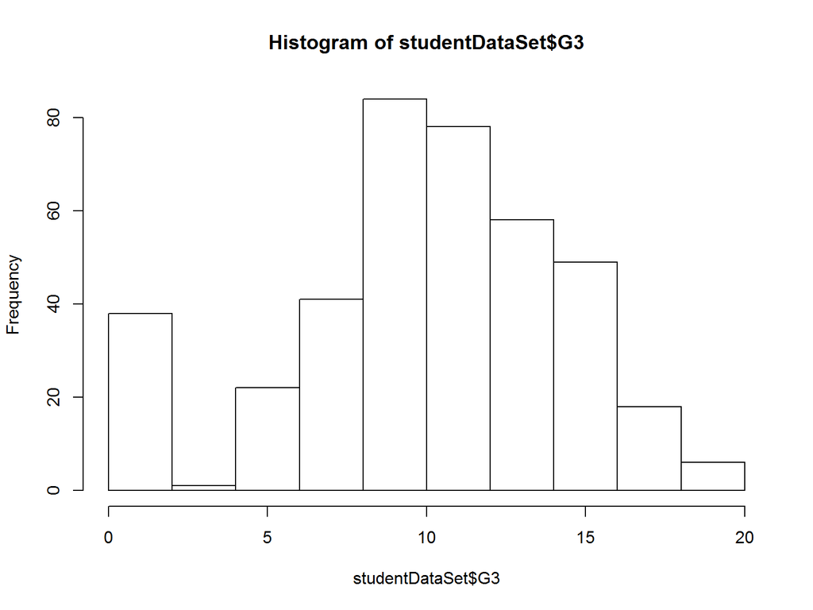

```r
library(ggplot2)
hist(studentDataSet$G3)
```

# 3)Feature Engneering

> > Selecton of features in the data set to improve machine Learning Results. We can modify/create new one by combining multiple different variables comes under feature Engineering Intriducing new feature to predict PASS or FAIL

```r
studentDataSet$finalGrade <- NULL
studentDataSet$finalGrade <- factor(ifelse(studentDataSet$G3>=median(studentDataSet$G3), 1, 0),labels = c("pass","fail"))
```

> > Feature Selection using information gain in R

> > syntax: best_feature <- information.gain(formulae,data)

```r
library(FSelector)
best_feature <- information.gain(finalGrade ~ .,studentDataSet)
print(best_feature)
```

```
##            attr_importance
## school        3.564076e-03
## sex           2.571527e-03
## age           0.000000e+00
## address       5.443534e-03
## famsize       8.505739e-04
## Pstatus       1.526086e-03
## Medu          0.000000e+00
## Fedu          0.000000e+00
## Mjob          2.043180e-02
## Fjob          4.593047e-03
## reason        2.480221e-03
## guardian      2.684456e-03
## traveltime    0.000000e+00
## studytime     0.000000e+00
## failures      4.659940e-02
## schoolsup     9.296121e-03
## famsup        5.031213e-04
## paid          9.277553e-04
## activities    2.161684e-05
## nursery       3.626333e-04
## higher        1.220407e-02
## internet      4.426085e-03
## romantic      4.107437e-05
## famrel        0.000000e+00
## freetime      0.000000e+00
## goout         0.000000e+00
## Dalc          0.000000e+00
## Walc          0.000000e+00
## health        0.000000e+00
## absences      0.000000e+00
## G1            4.061086e-01
## G2            5.190839e-01
## G3            6.914510e-01
```

```r
cutoff.biggest.diff(best_feature)
```

```
## [1] "G3" "G2" "G1"
```

> > checking for Null Values

```r
sum(is.na(studentDataSet))
```

```
## [1] 0
```

# 4)Normalization(to scale the attributes to (0-1) for the model accuracy)

> > Min-Max Normalization

```r
normalise <- function(x) {
  return((x - min(x)) / (max(x) - min(x)))
}

studentDataSet$G1 <- normalise(studentDataSet$G1)
studentDataSet$G2 <- normalise(studentDataSet$G2)
studentDataSet$goout <- normalise(studentDataSet$goout)
studentDataSet$absences <- normalise(studentDataSet$absences)
studentDataSet$failures <- normalise(studentDataSet$failures)
studentDataSet$Fedu <- normalise(studentDataSet$Fedu)
studentDataSet$Medu <- normalise(studentDataSet$Medu)
studentDataSet$health <- normalise(studentDataSet$health)
studentDataSet$Walc <- normalise(studentDataSet$Walc)
studentDataSet$Dalc <- normalise(studentDataSet$Dalc)
studentDataSet$traveltime <- normalise(studentDataSet$traveltime)
studentDataSet$studytime <- normalise(studentDataSet$studytime)
```

# 5)Data Exploration using Plots:

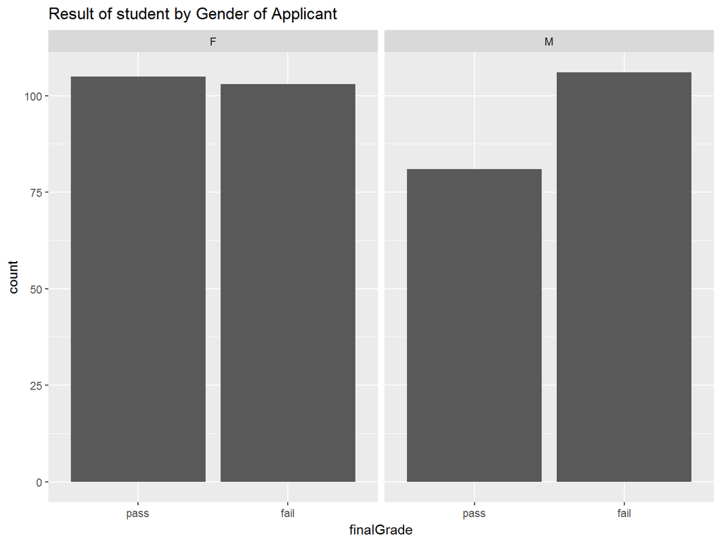

```r
library(ggplot2)


print(ggplot(studentDataSet, aes(x=finalGrade))+geom_bar()+facet_grid(.~sex)+ggtitle("Result of student by Gender of Applicant"))
```

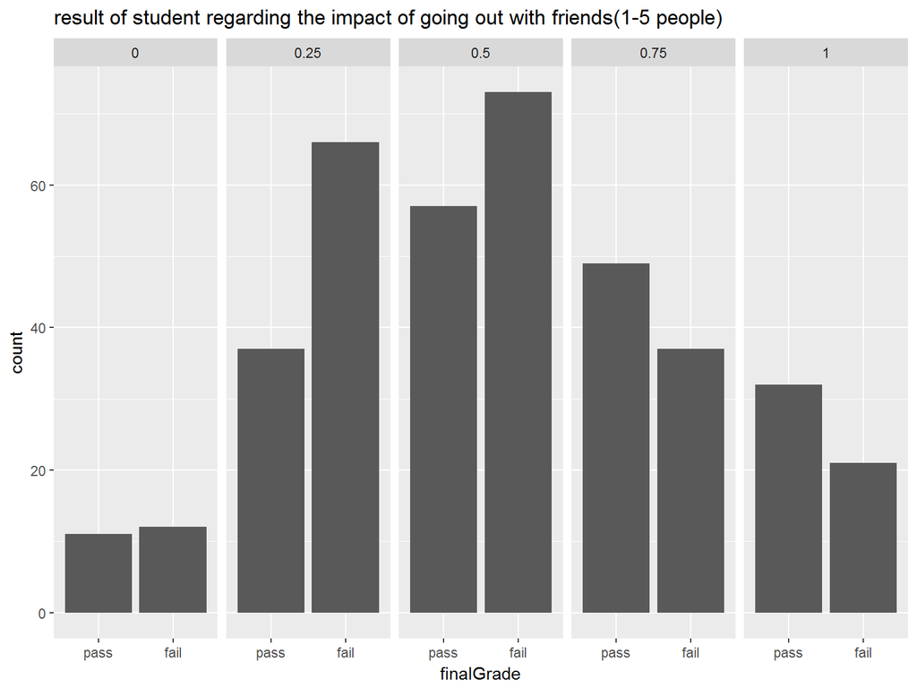

```r
print(ggplot(studentDataSet,aes(x=finalGrade)) + geom_bar()+facet_grid(.~goout)+ggtitle("result of student regarding the impact of going out with friends(1-5 people)"))
```

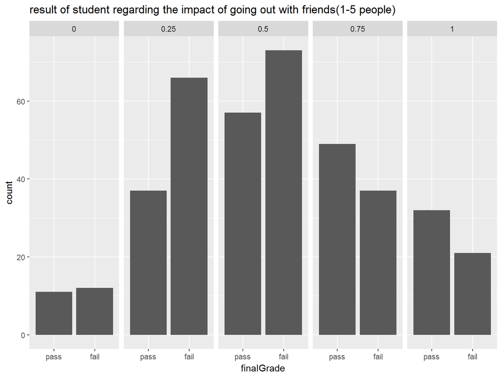

```r
print(ggplot(studentDataSet,aes(x=finalGrade)) + geom_bar()+facet_grid(.~goout)+ggtitle("result of student regarding the impact of going out with friends(1-5 people)"))
```

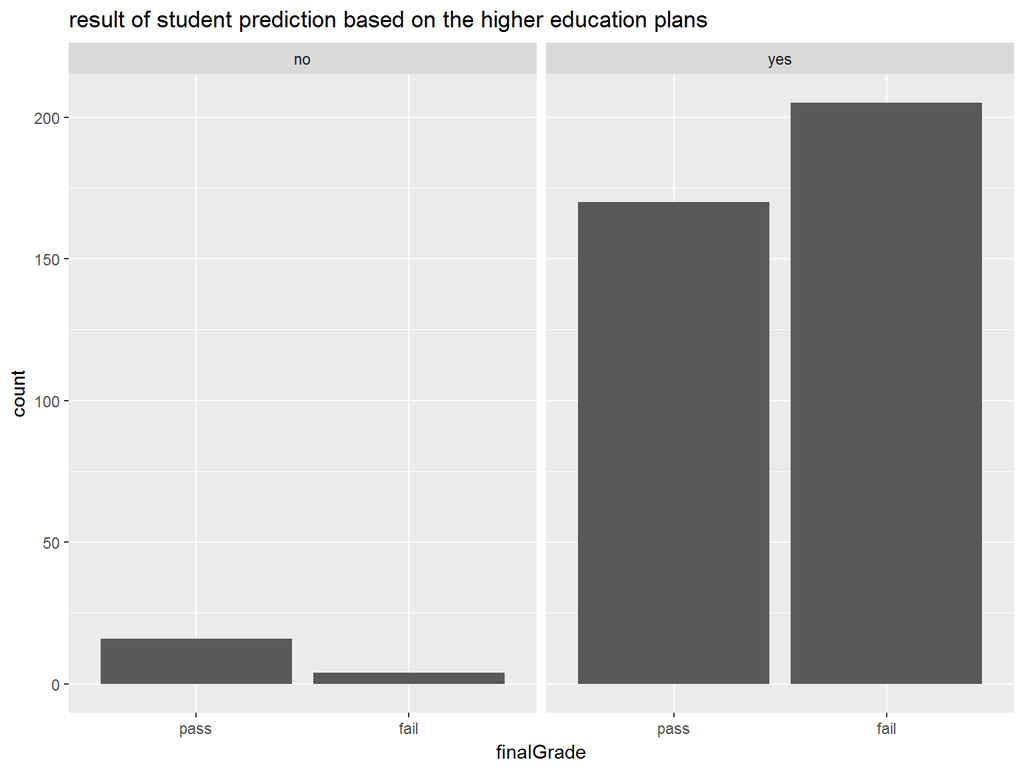

```r
print(ggplot(studentDataSet,aes(x=finalGrade)) + geom_bar()+facet_grid(.~higher)+ggtitle("result of student prediction based on the higher education plans"))
```

```r
#The number of students who has passes/failed in the Exam.
table(studentDataSet$finalGrade)
```

```
##
## pass fail
##  186  209
```

# 6)Testing and Training Samples

```r
studentDataSet_train <- studentDataSet[1:295,]
studentDataSet_test <- studentDataSet[295:395,]
```

# 7)Model Development using Decison Tree(C50)

```r
library("partykit")
```

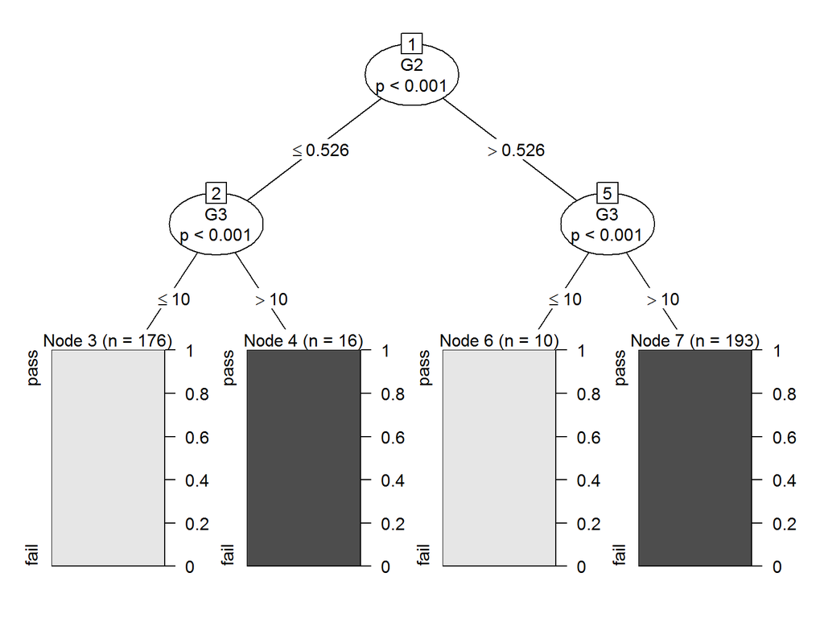

```r
# Create the tree.
output.tree <- ctree(finalGrade ~ ., data = studentDataSet)
plot(output.tree)
```

> > syntax: C5.0(train_data_set_excluding(target_variable and G3),target_variable) We are excluding G3 as well,since it is aso indirect target variable

```r
library(C50)
studentDataSet_model <- C5.0(studentDataSet_train[-c(33,34)],studentDataSet_train$finalGrade)
summary(studentDataSet_model)
```

```
##
## Call:
## C5.0.default(x = studentDataSet_train[-c(33, 34)], y
##  = studentDataSet_train$finalGrade)
##
##
## C5.0 [Release 2.07 GPL Edition]      Thu Jan 25 17:41:11 2018
## -------------------------------
##
## Class specified by attribute `outcome'
##
## Read 295 cases (33 attributes) from undefined.data
##
## Decision tree:
##
## G2 > 0.5263158: fail (149/5)
## G2 <= 0.5263158:
## :...G2 <= 0.4736842: pass (113/3)
##     G2 > 0.4736842:
##     :...Pstatus = A: fail (2)
##         Pstatus = T:
##         :...nursery = no: fail (8/3)
##             nursery = yes:
##             :...Medu <= 0.75: pass (14)
##                 Medu > 0.75:
##                 :...famsize = LE3: pass (3)
##                     famsize = GT3:
##                     :...Fedu <= 0.5: pass (2)
##                         Fedu > 0.5: fail (4)
##
##
## Evaluation on training data (295 cases):
##
##      Decision Tree
##    ----------------
##    Size      Errors
##
##       8   11( 3.7%)   <<
##
##
##     (a)   (b)    <-classified as
##    ----  ----
##     129     8    (a): class pass
##       3   155    (b): class fail
##
##
##  Attribute usage:
##
##  100.00% G2
##   11.19% Pstatus
##   10.51% nursery
##    7.80% Medu
##    3.05% famsize
##    2.03% Fedu
##
##
## Time: 0.0 secs
```

> > Syntax: predict(model_outcome,train_data)

```r
prediction_using_test_model <- predict(studentDataSet_model,studentDataSet_test)
table(prediction_using_test_model)
```

```
## prediction_using_test_model
## pass fail
##   37   64
```

> > To know the Model Accuracy in terms of actual pass/fail and predicted pass/fail for Test Data

```r
library(gmodels)
CrossTable(prediction_using_test_model,studentDataSet_test$finalGrade,prop.chisq = FALSE,
           prop.c = FALSE, prop.r = FALSE, dnn = c("actual pass",
                                                   "predicted pass"))
```

```
##
##
##    Cell Contents
## |-------------------------|
## |                       N |
## |         N / Table Total |
## |-------------------------|
##
##
## Total Observations in Table:  101
##
##
##              | predicted pass
##  actual pass |      pass |      fail | Row Total |
## -------------|-----------|-----------|-----------|
##         pass |        37 |         0 |        37 |
##              |     0.366 |     0.000 |           |
## -------------|-----------|-----------|-----------|
##         fail |        12 |        52 |        64 |
##              |     0.119 |     0.515 |           |
## -------------|-----------|-----------|-----------|
## Column Total |        49 |        52 |       101 |
## -------------|-----------|-----------|-----------|
##
##
```

> > Inference: Model incorrectly predicted total 12 outcomes out of 101 observation using Test Data

> > We can also use the trials parameter in C50 Algorithm for model accuracy

```r
library(C50)
library(gmodels)
studentDataSet_model_boost <- C5.0(studentDataSet_train[-c(33,34)],studentDataSet_train$finalGrade,trials = 10)
prediction_using_test_model_boost <- predict(studentDataSet_model_boost,studentDataSet_test)
CrossTable(prediction_using_test_model,studentDataSet_test$finalGrade,prop.chisq = FALSE,
           prop.c = FALSE, prop.r = FALSE, dnn = c("actual pass",
                                                   "predicted pass"))
```

```
##
##
##    Cell Contents
## |-------------------------|
## |                       N |
## |         N / Table Total |
## |-------------------------|
##
##
## Total Observations in Table:  101
##
##
##              | predicted pass
##  actual pass |      pass |      fail | Row Total |
## -------------|-----------|-----------|-----------|
##         pass |        37 |         0 |        37 |
##              |     0.366 |     0.000 |           |
## -------------|-----------|-----------|-----------|
##         fail |        12 |        52 |        64 |
##              |     0.119 |     0.515 |           |
## -------------|-----------|-----------|-----------|
## Column Total |        49 |        52 |       101 |
## -------------|-----------|-----------|-----------|
##
##
```

> > Let us view the decison tree in graph

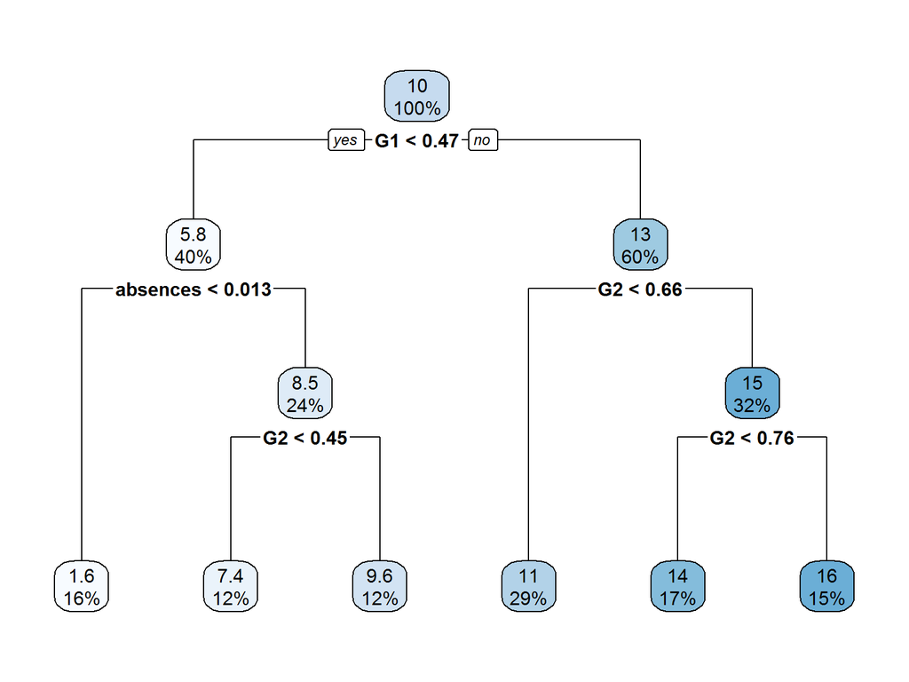

```r
library(rpart)
library(rpart.plot)
tree.model <- rpart(G3~.,studentDataSet_test)
rpart.plot(tree.model)
```

```r
#Let us view the decison tree in graph excluding the top 3 features(G1,G2,G3) to understand
tree.model_plot_extra <- rpart(data = studentDataSet_train[-c(31,32,33)], formula = finalGrade ~ .)
tree.model_plot_extra
```

```
## n= 295
##
## node), split, n, loss, yval, (yprob)
##       * denotes terminal node
##
##  1) root 295 137 fail (0.4644068 0.5355932)
##    2) failures>=0.1666667 55   8 pass (0.8545455 0.1454545) *
##    3) failures< 0.1666667 240  90 fail (0.3750000 0.6250000)
##      6) Mjob=at_home,teacher 73  32 pass (0.5616438 0.4383562)
##       12) goout>=0.375 50  16 pass (0.6800000 0.3200000)
##         24) Fjob=health,other,services 39   9 pass (0.7692308 0.2307692) *
##         25) Fjob=at_home,teacher 11   4 fail (0.3636364 0.6363636) *
##       13) goout< 0.375 23   7 fail (0.3043478 0.6956522) *
##      7) Mjob=health,other,services 167  49 fail (0.2934132 0.7065868)
##       14) sex=F 88  36 fail (0.4090909 0.5909091)
##         28) Mjob=other 48  22 pass (0.5416667 0.4583333)
##           56) Walc< 0.125 22   6 pass (0.7272727 0.2727273) *
##           57) Walc>=0.125 26  10 fail (0.3846154 0.6153846) *
##         29) Mjob=health,services 40  10 fail (0.2500000 0.7500000) *
##       15) sex=M 79  13 fail (0.1645570 0.8354430) *
```

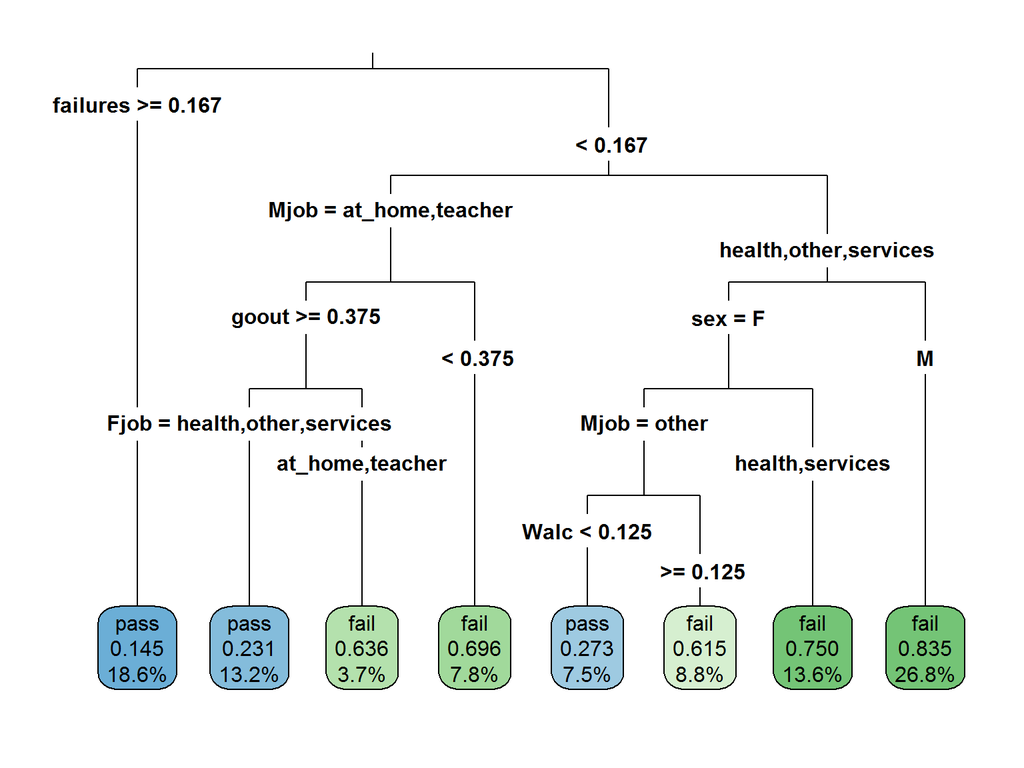

```r
rpart.plot(tree.model_plot_extra,type = 3,digits = 3,fallen.leaves = T)
```

# 8)Model Development using CARET Package(CART):

> > Training the Decision tree with criterian as information gain

```r
library(caret)
trctrl <- trctrl <- trainControl(method = "repeatedcv",number = 10,repeats = 3)

#Syntax: train(target_variable,data_set,...)

studentDataSet_model_2<- train(studentDataSet_train[-c(33,34)],studentDataSet_train$finalGrade,trControl = trctrl,method = "rpart",parms = list(split = "information"))
studentDataSet_model_2
```

```
## CART
##
## 295 samples
##  32 predictor
##   2 classes: 'pass', 'fail'
##
## No pre-processing
## Resampling: Cross-Validated (10 fold, repeated 3 times)
## Summary of sample sizes: 265, 266, 266, 265, 266, 266, ...
## Resampling results across tuning parameters:
##
##   cp           Accuracy   Kappa
##   0.000000000  0.9175862  0.8339291
##   0.003649635  0.9175862  0.8339291
##   0.861313869  0.7470881  0.4605054
##
## Accuracy was used to select the optimal model using the largest value.
## The final value used for the model was cp = 0.003649635.
```

```r
#Predict
prediction_using_model_2 <- predict(studentDataSet_model_2,studentDataSet_test)
table(prediction_using_model_2)
```

```
## prediction_using_model_2
## pass fail
##   46   55
```

Calculating Accuracy using cofusion Marix method

```r
confusionMatrix(prediction_using_model_2,studentDataSet_test$finalGrade)
```

```
## Confusion Matrix and Statistics
##
##           Reference
## Prediction pass fail
##       pass   44    2
##       fail    5   50
##
##                Accuracy : 0.9307
##                  95% CI : (0.8624, 0.9717)
##     No Information Rate : 0.5149
##     P-Value [Acc > NIR] : <2e-16
##
##                   Kappa : 0.861
##  Mcnemar's Test P-Value : 0.4497
##
##             Sensitivity : 0.8980
##             Specificity : 0.9615
##          Pos Pred Value : 0.9565
##          Neg Pred Value : 0.9091
##              Prevalence : 0.4851
##          Detection Rate : 0.4356
##    Detection Prevalence : 0.4554
##       Balanced Accuracy : 0.9297
##
##        'Positive' Class : pass
##
```

> > Training the Decision Tree classifier with criterion as gini index

```r
student_model_gini <- train(studentDataSet_train[-c(33,34)],studentDataSet_train$finalGrade,method = "rpart",parms = list(split = "gini"),trControl=trctrl,tuneLength=10)



test_pred_gini <- predict(student_model_gini, newdata = studentDataSet_test)
summary(test_pred_gini)
```

```
## pass fail
##   46   55
```

```r
confusionMatrix(test_pred_gini, studentDataSet_test$finalGrade)
```

```
## Confusion Matrix and Statistics
##
##           Reference
## Prediction pass fail
##       pass   44    2
##       fail    5   50
##
##                Accuracy : 0.9307
##                  95% CI : (0.8624, 0.9717)
##     No Information Rate : 0.5149
##     P-Value [Acc > NIR] : <2e-16
##
##                   Kappa : 0.861
##  Mcnemar's Test P-Value : 0.4497
##
##             Sensitivity : 0.8980
##             Specificity : 0.9615
##          Pos Pred Value : 0.9565
##          Neg Pred Value : 0.9091
##              Prevalence : 0.4851
##          Detection Rate : 0.4356
##    Detection Prevalence : 0.4554
##       Balanced Accuracy : 0.9297
##
##        'Positive' Class : pass
##
```

# 9)Comparing the result obtained from criteria as gini index and information gain for accuracy of the data_set

```r
result <- resamples(list(informaton_gain=studentDataSet_model_2,gini=student_model_gini))
summary(result)
```

```
##
## Call:
## summary.resamples(object = result)
##
## Models: informaton_gain, gini
## Number of resamples: 30
##
## Accuracy
##                      Min.   1st Qu.    Median      Mean   3rd Qu. Max.
## informaton_gain 0.8275862 0.8741379 0.9310345 0.9175862 0.9655172    1
## gini            0.8333333 0.8974138 0.9488095 0.9358210 0.9666667    1
##                 NA's
## informaton_gain    0
## gini               0
##
## Kappa
##                      Min.   1st Qu.   Median      Mean   3rd Qu. Max. NA's
## informaton_gain 0.6572104 0.7464437 0.862232 0.8339291 0.9297821    1    0
## gini            0.6696035 0.7957447 0.897914 0.8717022 0.9333333    1    0
```

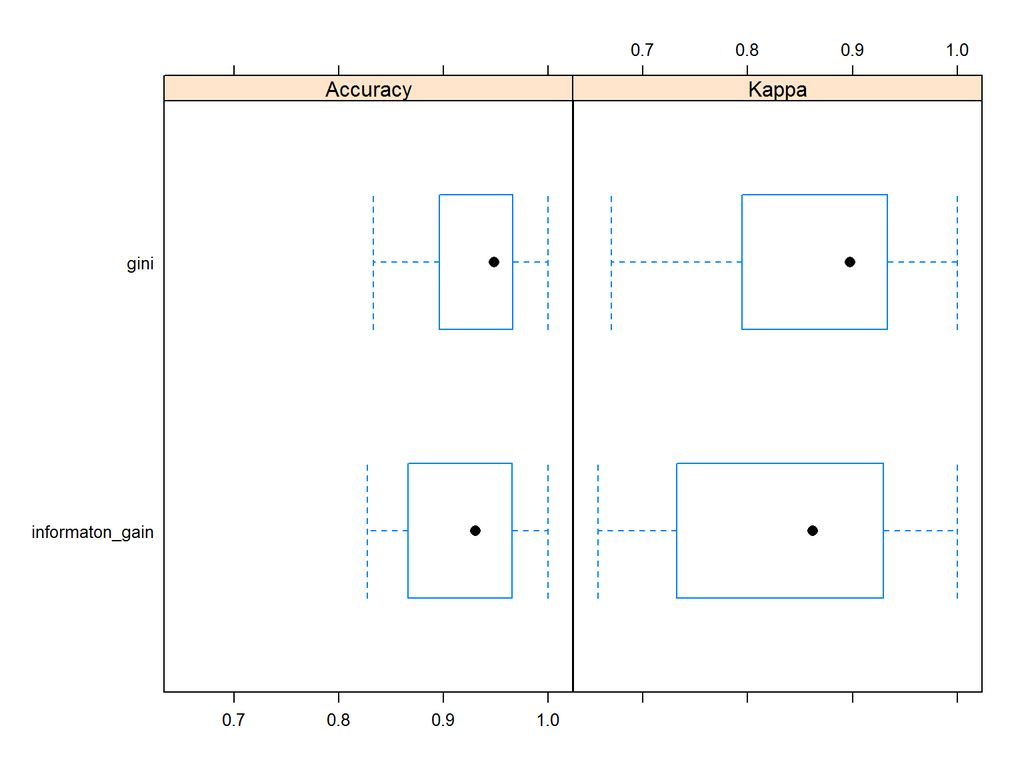

```r
bwplot(result)
```